# lab-01

2026-02-06

# Laboratorio 1: Análisis Exploratorio (CineVision Studios)

# 1. Exploración rápida (resumen del dataset)

**Enunciado:** Haga una exploración rápida de sus datos, para eso haga un resumen de su conjunto de datos.

```
##        id              budget             genres            homePage
##  Min.   :      5   Min.   :        0   Length:19883       Length:19883
##  1st Qu.: 146220   1st Qu.:        0   Class :character   Class :character
##  Median : 869623   Median :        0   Mode  :character   Mode  :character
##  Mean   : 902240   Mean   :  9413280
##  3rd Qu.:1589602   3rd Qu.:  1000000
##  Max.   :1627166   Max.   :380000000
##
##  productionCompany  productionCompanyCountry productionCountry
##  Length:19883       Length:19883             Length:19883
##  Class :character   Class :character         Class :character
##  Mode  :character   Mode  :character         Mode  :character
##
##
##
##
##     revenue             runtime         video           director
##  Min.   :0.000e+00   Min.   :  0.00   Mode :logical   Length:19883
##  1st Qu.:0.000e+00   1st Qu.: 10.00   FALSE:19313     Class :character
##  Median :0.000e+00   Median : 86.00   TRUE :84        Mode  :character
##  Mean   :2.879e+07   Mean   : 66.09   NA's :486
##  3rd Qu.:3.306e+05   3rd Qu.:103.00
##  Max.   :2.847e+09   Max.   :750.00
##
##     actors          actorsPopularity   actorsCharacter    originalTitle
##  Length:19883       Length:19883       Length:19883       Length:19883
##  Class :character   Class :character   Class :character   Class :character
##  Mode  :character   Mode  :character   Mode  :character   Mode  :character
##
##
##
##
##     title           originalLanguage     popularity        releaseDate
##  Length:19883       Length:19883       Min.   :0.000e+00   Length:19883
##  Class :character   Class :character   1st Qu.:5.460e-02   Class :character
##  Mode  :character   Mode  :character   Median :8.502e+00   Mode  :character
##                                        Mean   :2.625e+01
##                                        3rd Qu.:2.224e+01
##                                        Max.   :1.147e+04
##
```

[output cut: 9 more lines]

```
##  Min.   :  0.00            Min.   :     0   Min.   :     0   Min.   :     0
##  1st Qu.:  1.00            1st Qu.:     3   1st Qu.:     0   1st Qu.:     0
##  Median :  1.00            Median :     9   Median :     2   Median :     3
##  Mean   :  1.23            Mean   :  1082   Mean   :  3517   Mean   :  8224
##  3rd Qu.:  1.00            3rd Qu.:    21   3rd Qu.:     6   3rd Qu.:    12
##  Max.   :155.00            Max.   :919590   Max.   :922162   Max.   :922017
##                                             NA's   :37       NA's   :162
##   releaseYear
##  Min.   :1902
##  1st Qu.:2013
##  Median :2021
##  Mean   :2017
##  3rd Qu.:2025
##  Max.   :2026
##  NA's   :2
```

# 2. Tipo de cada variable

**Enunciado:** Diga el tipo de cada una de las variables (cualitativa ordinal o nominal, cuantitativa continua, cuantitativa discreta).

| variable | tipo | descripcion |
| --- | --- | --- |
| id | Cualitativa nominal | Identificador; numérico pero no mide magnitud |
| popularity | Cuantitativa continua | Índice (escala continua) |
| budget | Cuantitativa continua | Presupuesto (moneda) |
| revenue | Cuantitativa continua | Ingresos (moneda) |
| originalTitle | Cualitativa nominal | Texto |
| originalLanguage | Cualitativa nominal | Código de idioma |
| title | Cualitativa nominal | Texto (título en inglés) |
| homePage | Cualitativa nominal | URL (alta cardinalidad, muchos NA) |
| video | Cualitativa nominal | Binaria (sí/no) |
| director | Cualitativa nominal | Nombre (alta cardinalidad) |
| runtime | Cuantitativa continua | Duración (minutos; medida de tiempo) |
| genres | Cualitativa nominal | Multi-etiqueta (separada por coma o ‘\|’) |
| genresAmount | Cuantitativa discreta | Conteo de géneros |
| productionCompany | Cualitativa nominal | Texto / multi-etiqueta (según fuente) |
| productionCoAmount | Cuantitativa discreta | Conteo de compañías productoras |
| productionCompanyCountry | Cualitativa nominal | Multi-etiqueta (códigos de país) |
| productionCountry | Cualitativa nominal | Multi-etiqueta (códigos de país) |
| productionCountriesAmount | Cuantitativa discreta | Conteo de países |
| releaseDate | Cualitativa ordinal | Fecha (tiene orden temporal) |
| voteCount | Cuantitativa discreta | Conteo de votos |
| voteAvg | Cuantitativa continua | Promedio (0–10) |
| actors | Cualitativa nominal | Lista de actores (texto, separada por coma o ‘\|’) |
| actorsPopularity | Cuantitativa continua | Popularidad del elenco (numérica o derivable) |
| actorsCharacter | Cualitativa nominal | Lista de personajes (texto) |
| actorsAmount | Cuantitativa discreta | Conteo de actores |
| castWomenAmount | Cuantitativa discreta | Conteo de actrices |
| castMenAmount | Cuantitativa discreta | Conteo de actores |
| releaseYear | Cuantitativa discreta | Año |

# 3. Normalidad en variables cuantitativas y tabla de frecuencias de cualitativas

**Enunciado:** Investigue si las variables cuantitativas siguen una distribución normal y haga una tabla de frecuencias de las variables cualitativas. Explique todos los resultados.

> Nota: con muestras muy grandes, pruebas como Shapiro-Wilk tienden a rechazar normalidad por desviaciones pequeñas.  
> Por eso se evalúa sobre una muestra aleatoria y se apoya con gráficos.

Prueba Shapiro-Wilk (muestra) para variables numéricas

| variable | n | p_value |
| --- | --- | --- |
| actorsAmount | 5000 | 0 |
| castWomenAmount | 4993 | 0 |
| popularity | 5000 | 0 |
| castMenAmount | 4968 | 0 |
| revenue | 5000 | 0 |
| productionCountriesAmount | 5000 | 0 |
| voteCount | 5000 | 0 |
| budget | 5000 | 0 |
| releaseYear | 5000 | 0 |
| id | 5000 | 0 |
| productionCoAmount | 5000 | 0 |
| voteAvg | 5000 | 0 |
| runtime | 5000 | 0 |
| genresAmount | 5000 | 0 |

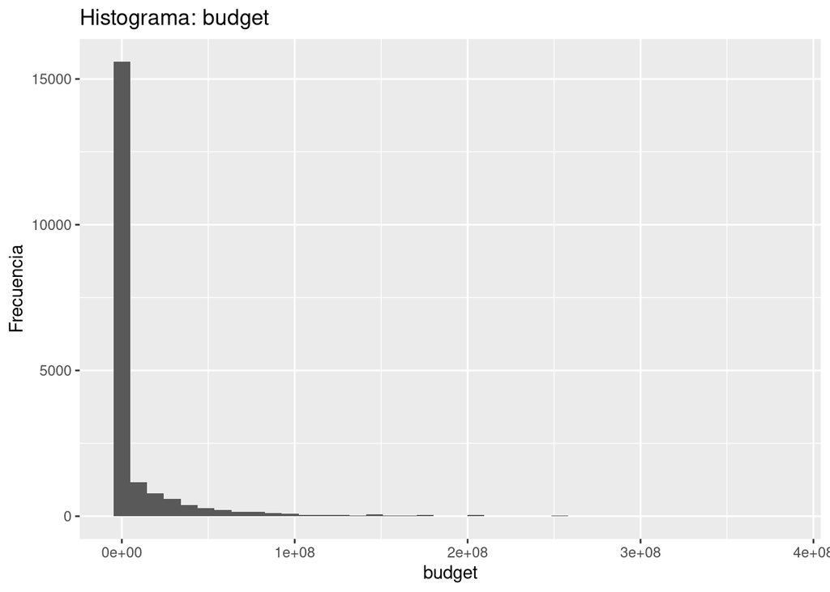

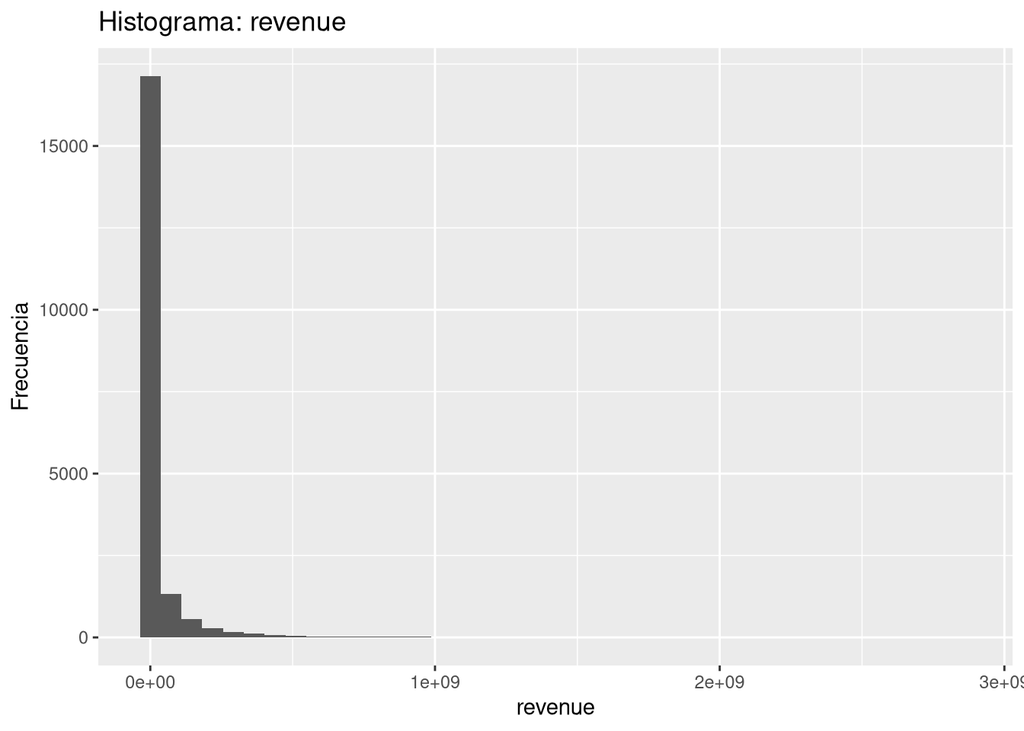

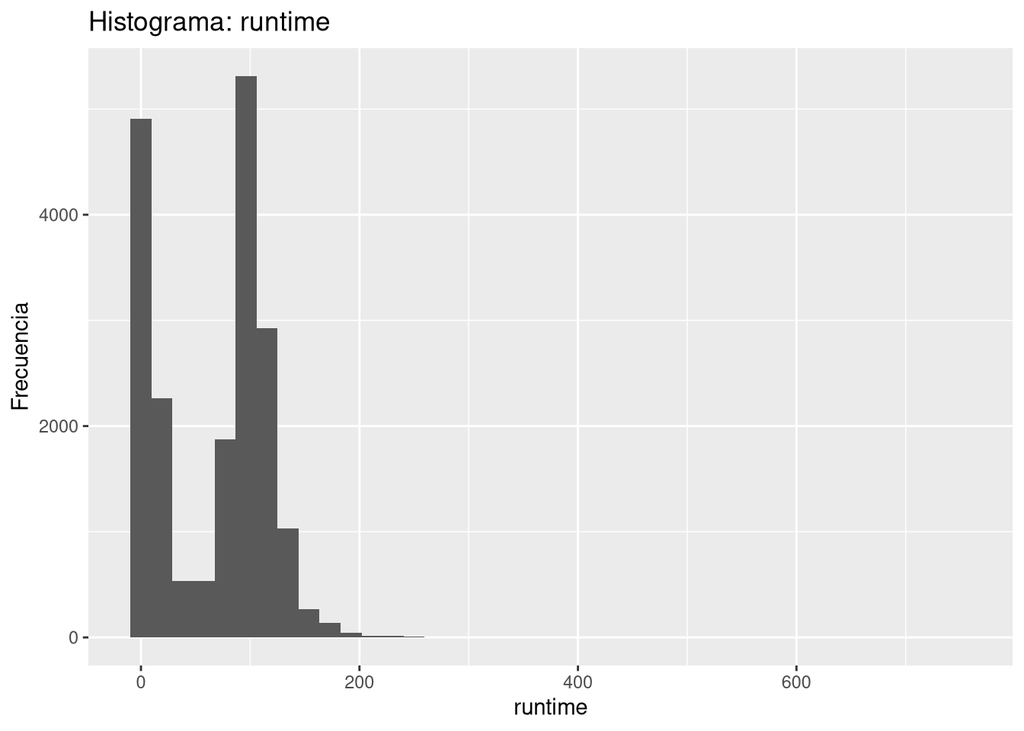

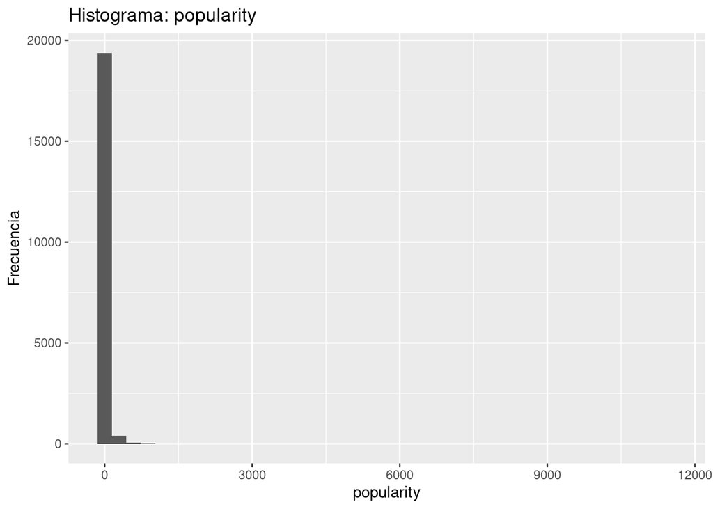

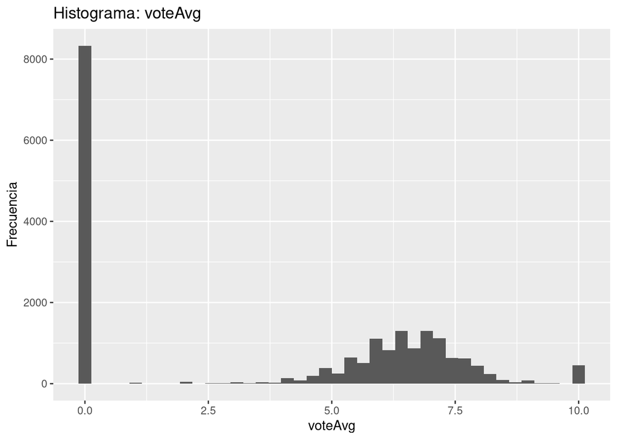

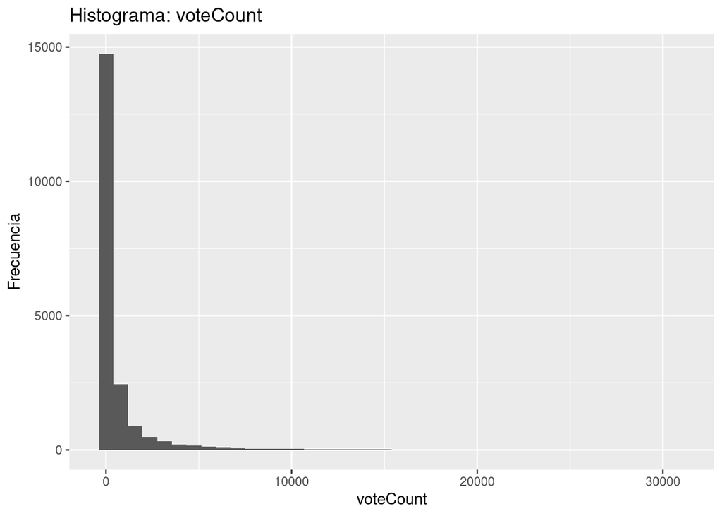

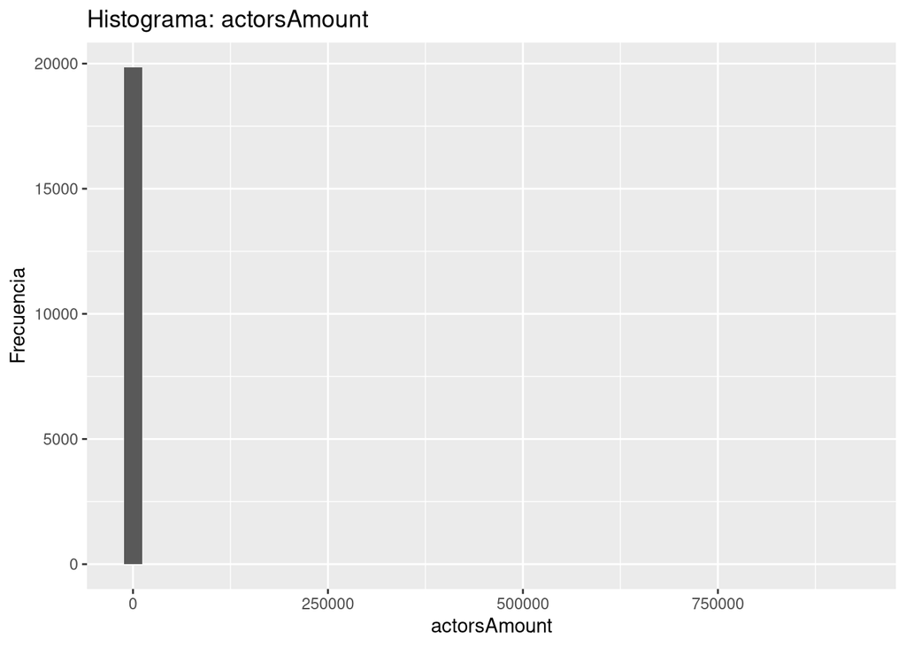

```
##                    variable                      top  freq unicos missing
## 1                     video                    FALSE 19313      3     486
## 2                  homePage                     <NA> 14276   5488   14276
## 3          originalLanguage                       en 11961     94       0
## 4  productionCompanyCountry                     <NA>  8410   2745    8410
## 5         productionCompany                     <NA>  5656  12235    5656
## 6         productionCountry United States of America  4968   1407    3874
## 7           actorsCharacter                     <NA>  2835  14969    2835
## 8          actorsPopularity                     <NA>  2608  15135    2608
## 9                    actors                     <NA>  2601  16734    2601
## 10                   genres                     <NA>  1965   2828    1965
## 11                 director                     <NA>   976  13669     976
## 12              releaseDate               2026-01-30   263   5664       2
## 13                    title               Cinderella     5  19384       0
## 14            originalTitle               Cinderella     4  19506       0
```

# 4. Preguntas de negocio

## 4.1 ¿Cuáles son las 10 películas que contaron con más presupuesto?

```
##                                          title   budget releaseYear
## 1  Pirates of the Caribbean: On Stranger Tides 3.80e+08        2011
## 2                      Avengers: Age of Ultron 3.65e+08        2015
## 3                            Avengers: Endgame 3.56e+08        2019
## 4                         Avatar: Fire and Ash 3.50e+08        2025
## 5     Pirates of the Caribbean: At World's End 3.00e+08        2007
## 6                               Justice League 3.00e+08        2017
## 7                       Avengers: Infinity War 3.00e+08        2018
## 8                             Superman Returns 2.70e+08        2006
## 9                                      Tangled 2.60e+08        2010
## 10                               The Lion King 2.60e+08        2019
##                     director
## 1               Rob Marshall
## 2                Joss Whedon
## 3    Anthony Russo|Joe Russo
## 4              James Cameron
## 5             Gore Verbinski
## 6                Zack Snyder
## 7    Anthony Russo|Joe Russo
## 8               Bryan Singer
## 9  Byron Howard|Nathan Greno
## 10               Jon Favreau
```

## 4.2 ¿Cuáles son las 10 películas que más ingresos tuvieron?

```
##                           title    revenue   budget releaseYear
## 1                        Avatar 2847246203 2.37e+08        2009
## 2             Avengers: Endgame 2797800564 3.56e+08        2019
## 3                       Titanic 2187463944 2.00e+08        1997
## 4  Star Wars: The Force Awakens 2068223624 2.45e+08        2015
## 5        Avengers: Infinity War 2046239637 3.00e+08        2018
## 6                    Zootopia 2 1744338246 1.50e+08        2025
## 7                Jurassic World 1671713208 1.50e+08        2015
## 8                 The Lion King 1667635327 2.60e+08        2019
## 9       Spider-Man: No Way Home 1631853496 2.00e+08        2021
## 10                 The Avengers 1518815515 2.20e+08        2012
##                   director
## 1            James Cameron
## 2  Anthony Russo|Joe Russo
## 3            James Cameron
## 4              J.J. Abrams
## 5  Anthony Russo|Joe Russo
## 6  Jared Bush|Byron Howard
## 7          Colin Trevorrow
## 8              Jon Favreau
## 9                Jon Watts
## 10             Joss Whedon
```

## 4.3 ¿Cuál es la película que más votos tuvo?

```
##           title voteCount voteAvg
## 13402 Inception     30788     8.4
```

## 4.4 ¿Cuál es la peor película de acuerdo a los votos de todos los usuarios?

> Se interpreta como la película con menor **voteAvg**.  
> Para evitar casos con muy pocos votos (p.ej. 1 voto), se muestra también el peor caso considerando un umbral de votos.

```
## $peor_sin_filtro
##                   title voteAvg voteCount
## 1 The Halloween Harvest       0         1
##
## $peor_con_umbral
##        title voteAvg voteCount
## 1 Death Note     4.2      3388
```

## 4.5 ¿Cuántas películas se hicieron en cada año? ¿En qué año se hicieron más películas? (gráfico de barras)

```
##    releaseYear peliculas
## 1         2025      7351
## 2         2026      2537
## 3         2021       814
## 4         2018       628
## 5         2017       617
## 6         2019       611
## 7         2016       557
## 8         2020       531
## 9         2015       450
## 10        2014       432
```

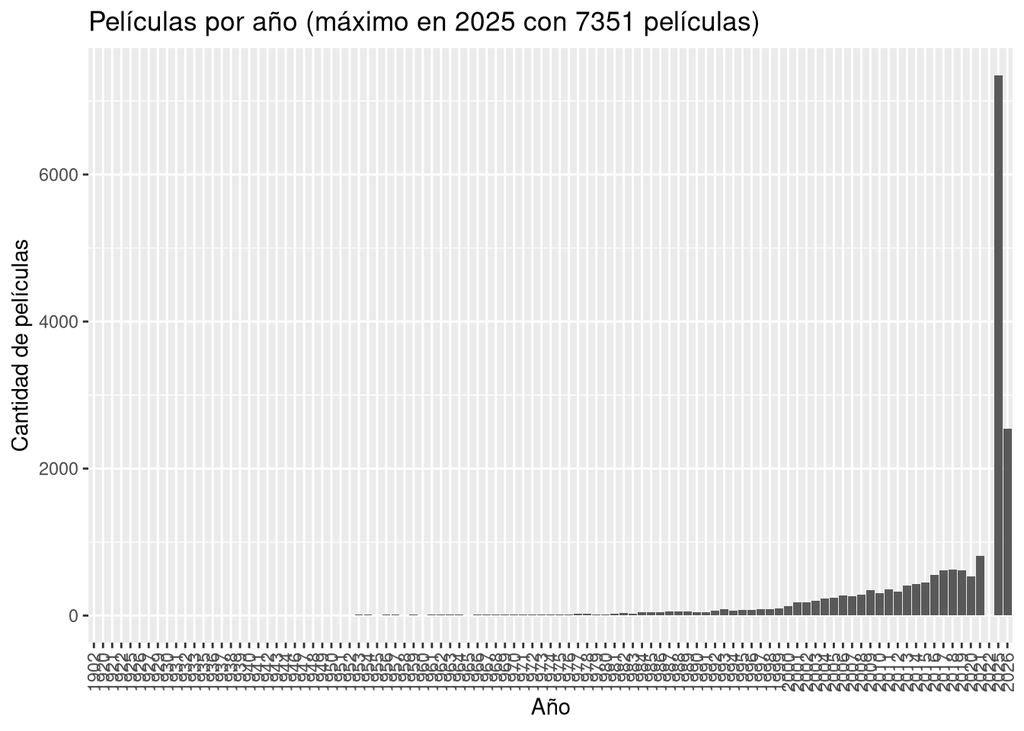

## 4.6 Género principal de las 20 películas más recientes, género predominante y género de películas más largas

```
##                                              title releaseDate  main_genre
## 1                                     A Fading Man  2026-05-07       Drama
## 2        Elon Musk Unveiled – The Tesla Experiment  2026-03-12 Documentary
## 3                                            Skunk  2026-02-25        <NA>
## 4                                        Anastasia  2026-02-25        <NA>
## 5                                Nikki hako no koi  2026-02-06        <NA>
## 6                                         Immersed  2026-02-01       Drama
## 7                                       Cinderella  2026-02-01   Animation
## 8                                          Aladdin  2026-02-01   Animation
## 9                            THE RING AND THE DECK  2026-02-01    Thriller
## 10                                  Crimson High 3  2026-02-01   Animation
## 11 Conversations with Rasparagus Asparagus Baragus  2026-02-01      Comedy
## 12                                 Highway To Hell  2026-02-01      Comedy
## 13                                 Pari's daughter  2026-02-01       Drama
## 14                                          Escort  2026-02-01      Action
## 15                                           Dream  2026-02-01       Drama
## 16                                          Lively  2026-02-01       Drama
## 17                              قایق‌سواری در تهران  2026-02-01     Romance
## 18                                        Midnight  2026-02-01         War
## 19             Emir - Posljednji dalmatinski težak  2026-02-01        <NA>
## 20                                Our Dead Husband  2026-02-01    Thriller
```

```
##    main_genre n
## 1       Drama 5
## 2        <NA> 4
## 3   Animation 3
## 4      Comedy 2
## 5    Thriller 2
## 6      Action 1
## 7 Documentary 1
## 8     Romance 1
## 9         War 1
```

```
##         main_genre    n
## 1            Drama 3734
## 2           Comedy 2640
## 3      Documentary 2245
## 4             <NA> 1965
## 5           Action 1760
## 6           Horror 1513
## 7        Animation 1247
## 8         Thriller  854
## 9        Adventure  629
## 10         Romance  585
## 11           Crime  497
## 12          Family  469
## 13 Science Fiction  437
## 14           Music  373
## 15         Fantasy  364
```

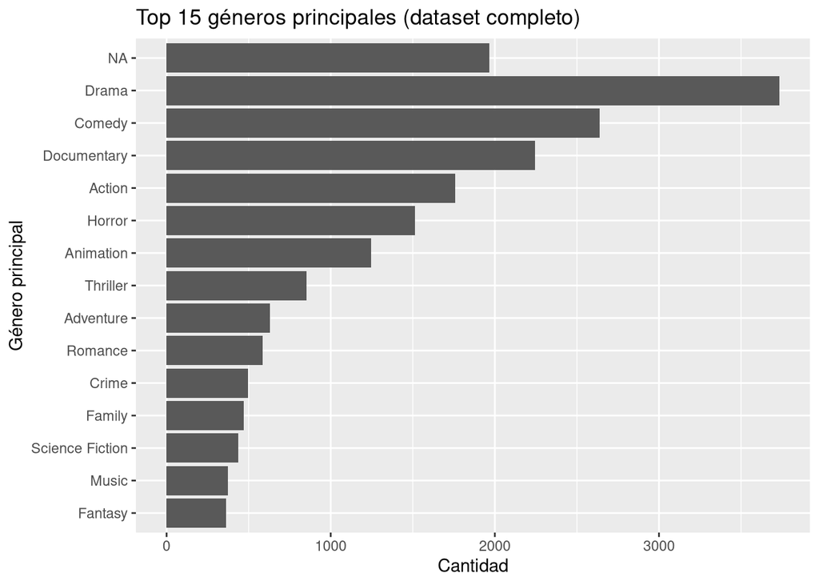

```
##                                                             title runtime
## 1           How Ponyo was Born ~Hayao Miyazaki's Thought Process~     750
## 2                                                  Before the End     675
## 3                   League of Legends Worlds25 - Finals in Cinema     420
## 4  Crystal Lake Memories: The Complete History of Friday the 13th     400
## 5                                In Search of Darkness: 1995-1999     384
## 6                                    Vu 2025 (l’année du zapping)     366
## 7                                                        Napoleon     333
## 8                            White Gardenia: The King James Bible     330
## 9                                         NJPW Wrestle Kingdom 20     326
## 10                                                           1900     317
## 11                        The Idolm@ster Gakuen: Story of Re;IRIS     284
## 12                            Shpongle - Live at Mission Ballroom     263
## 13                                                     Indie Beat     261
## 14               2025 Rock & Roll Hall of Fame Induction Ceremony     261
```

[output cut: 27 more lines]

```
##    main_genre n
## 1        <NA> 5
## 2 Documentary 4
## 3       Drama 4
## 4      Action 3
## 5       Music 2
## 6   Animation 1
## 7      Horror 1
```

## 4.7 ¿Las películas de qué género principal obtuvieron mayores ganancias?

> Se calcula **ganancia** como `revenue - budget` para películas con ambos valores positivos.

```
## # A tibble: 15 × 4
##    main_genre      peliculas ganancia_total ganancia_promedio
##    <chr>               <int>          <dbl>             <dbl>
##  1 Action                779    92195613009        118351236.
##  2 Adventure             351    60354070276        171948918.
##  3 Comedy                805    49220834911         61143894.
##  4 Drama                 860    42588500938         49521513.
##  5 Animation             181    32005682028        176826973.
##  6 Horror                373    18026440092         48328258.
##  7 Family                132    17978264869        136198976.
##  8 Science Fiction       145    17757646253        122466526.
##  9 Fantasy               137    15146197026        110556183.
## 10 Thriller              201    10151243101         50503697.
## 11 Crime                 211     8254157389         39119229.
## 12 Romance               106     6325555484         59675052.
## 13 War                    41     3379441894         82425412.
## 14 Mystery                60     3378308280         56305138
## 15 Music                  35     2174083494         62116671.
```

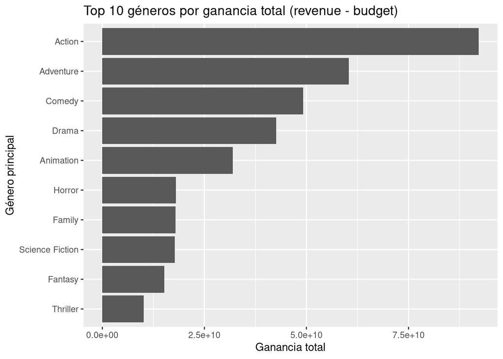

## 4.8 ¿La cantidad de actores influye en los ingresos? ¿Se han hecho películas con más actores en los últimos años?

```
## [1] 0.4469277
```

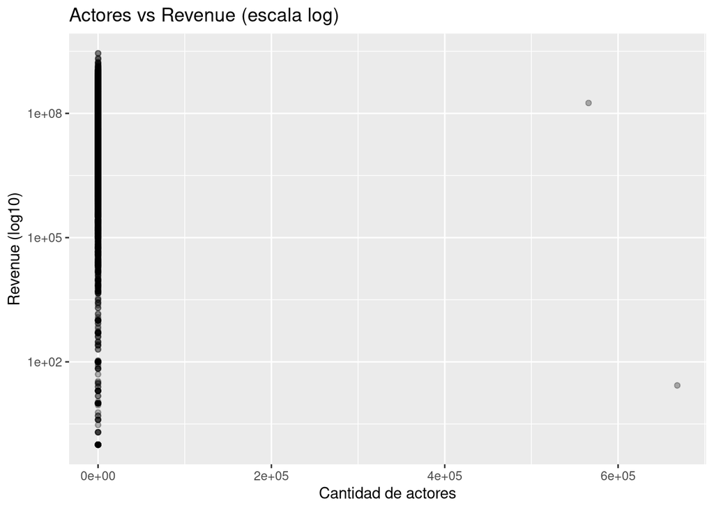

```
## # A tibble: 10 × 3
##    releaseYear actores_prom peliculas
##          <int>        <dbl>     <int>
##  1        2015      1419.         445
##  2        2016      4179.         548
##  3        2017      3634.         611
##  4        2018      3934.         623
##  5        2019      2154.         599
##  6        2020      2903.         520
##  7        2021      3331.         781
##  8        2022        12.1          7
##  9        2025         5.10      5412
## 10        2026         5.22      1955
```

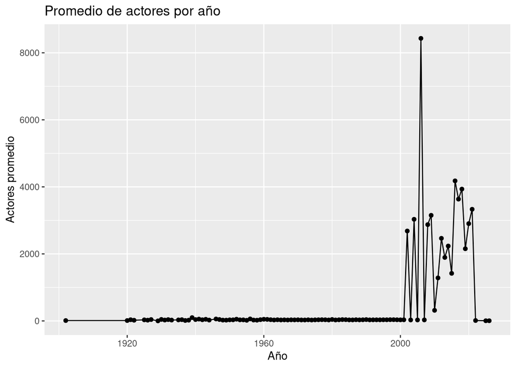

## 4.9 ¿La cantidad de hombres y mujeres en el reparto influye en la popularidad y los ingresos?

```
## $corr_prop_mujeres_popularity
## [1] 0.09198082
##
## $corr_prop_mujeres_revenue
## [1] -0.004383732
```

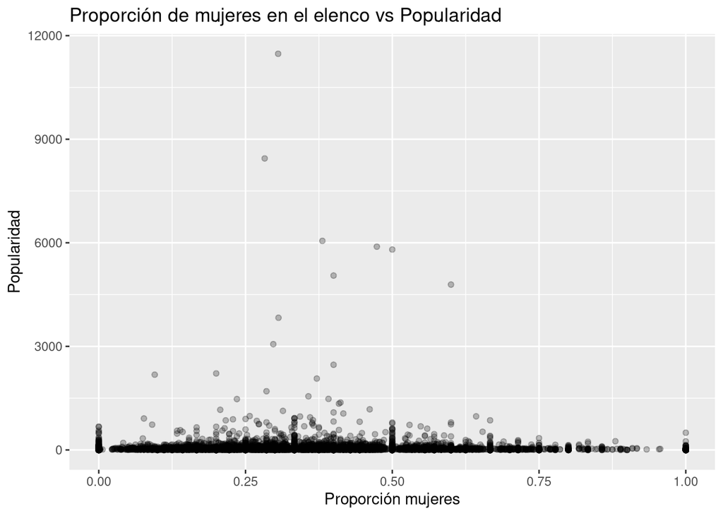

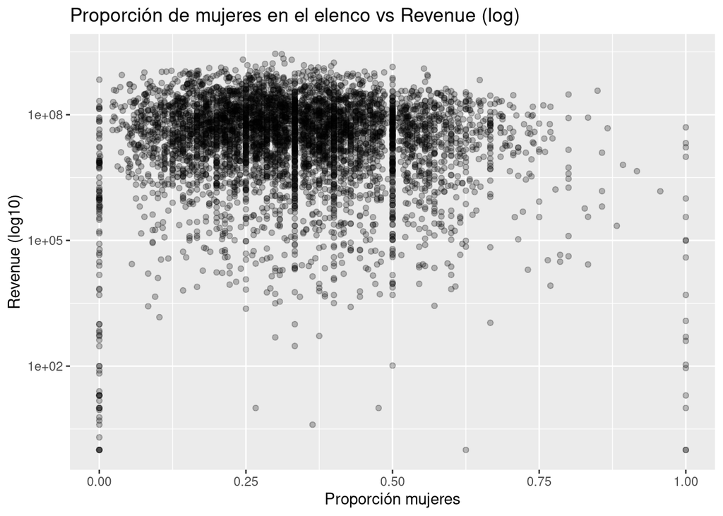

## 4.10 ¿Quiénes son los directores que hicieron las 20 películas mejor calificadas?

> Para hacerlo más robusto, se filtra al 10% de películas con más votos y luego se ordena por **voteAvg** y **voteCount**.

```
##                   director                                         title
## 10050       Frank Darabont                      The Shawshank Redemption
## 10026 Francis Ford Coppola                                 The Godfather
## 13070        Aditya Chopra                   Dilwale Dulhania Le Jayenge
## 10108     Steven Spielberg                              Schindler's List
## 10028 Francis Ford Coppola                        The Godfather: Part II
## 16495       Makoto Shinkai                                    Your Name.
## 19218           Tosca Musk                             Gabriel's Inferno
## 9978     Christopher Nolan                               The Dark Knight
## 10265    Quentin Tarantino                                  Pulp Fiction
## 9895       Robert Zemeckis                                  Forrest Gump
## 9959         Peter Jackson The Lord of the Rings: The Return of the King
## 10140       Frank Darabont                                The Green Mile
## 17808         Bong Joon-ho                                      Parasite
## 9962        Hayao Miyazaki                                 Spirited Away
```

[output cut: 27 more lines]

## 4.11 ¿Cómo se correlacionan los presupuestos con los ingresos? (histograma y dispersión)

```
## [1] 0.7057162
```

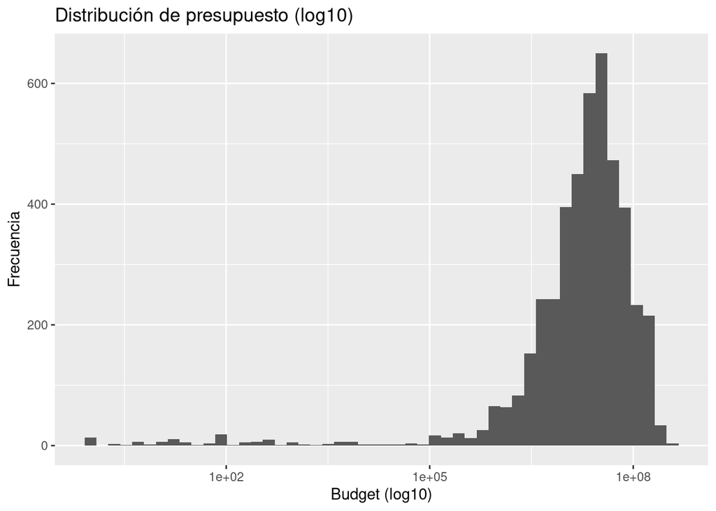

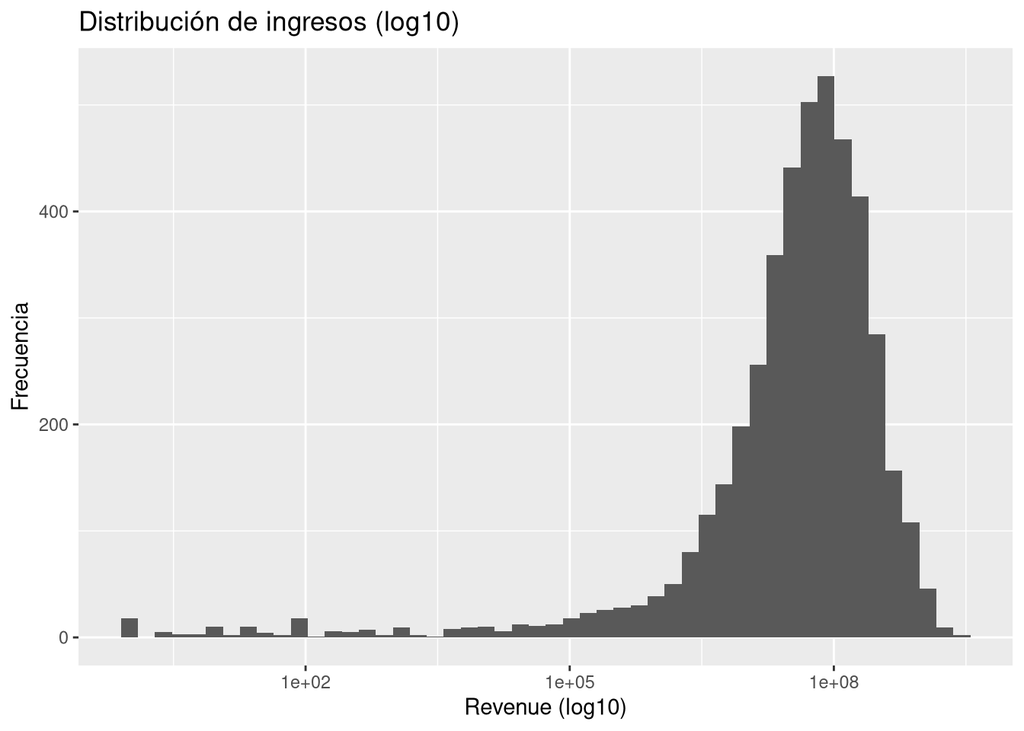

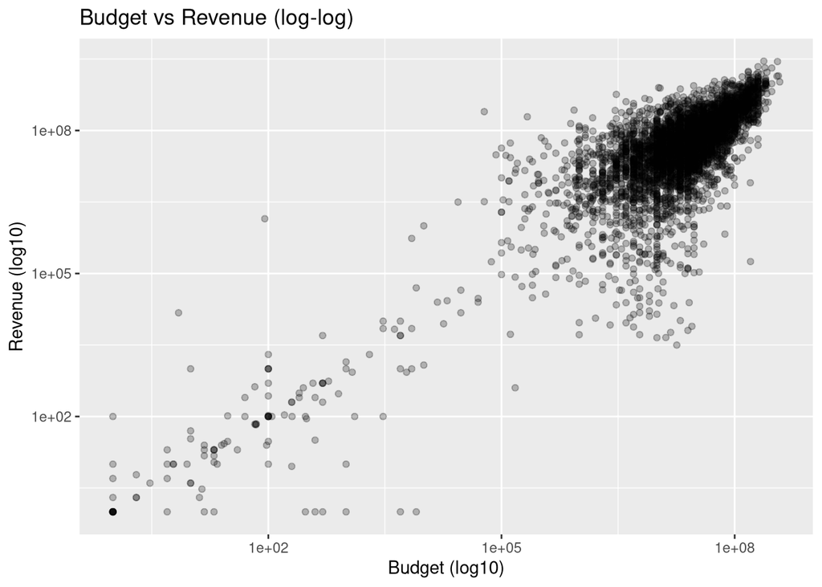

## 4.12 ¿Se asocian ciertos meses de lanzamiento con mejores ingresos?

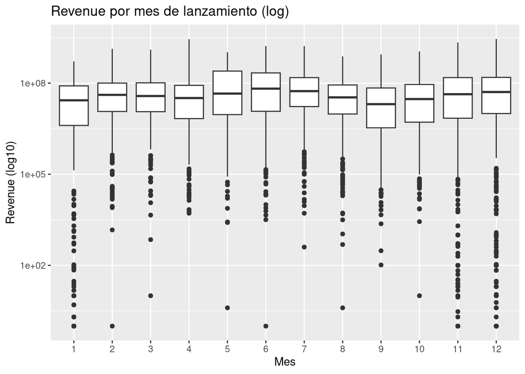

```
## # A tibble: 12 × 4
##    releaseMonth peliculas revenue_prom revenue_mediana
##           <int>     <int>        <dbl>           <dbl>
##  1            6       468   165807439.       66001002
##  2            5       371   165272557.       45361000
##  3            7       465   132764089.       54682547
##  4           11       470   127811630.       43278503
##  5           12       579   124411468.       51053787
##  6            4       358   102252891.       32339075
##  7            3       429    97108375.       37713879
##  8           10       489    85148627.       29918745
##  9            2       366    82768572.       41146058
## 10            8       464    70777333.       34032922.
## 11            1       368    60407604.       27233270
## 12            9       571    60335029.       20350754
```

## 4.13 ¿En qué meses se han visto los lanzamientos con mejores ingresos? ¿Cuántas películas, en promedio, se han lanzado por mes?

```
## # A tibble: 12 × 4
##      Mes revenue_total revenue_prom peliculas
##    <int>         <dbl>        <dbl>     <int>
##  1     6   77597881637    94747108.       819
##  2    12   72034239751    16517826.      4361
##  3     7   61735301475    76028696.       812
##  4     5   61316118519    87719769.       699
##  5    11   60071466034    12700099.      4730
##  6     3   41659492701    51053300.       816
##  7    10   41637678840    39133157.      1064
##  8     4   36606534881    52671273.       695
##  9     9   34451301833    31958536.      1078
## 10     8   32840682550    35930725.       914
## 11     2   30293297436    39138627.       774
## 12     1   22229998382     7127284.      3119
```

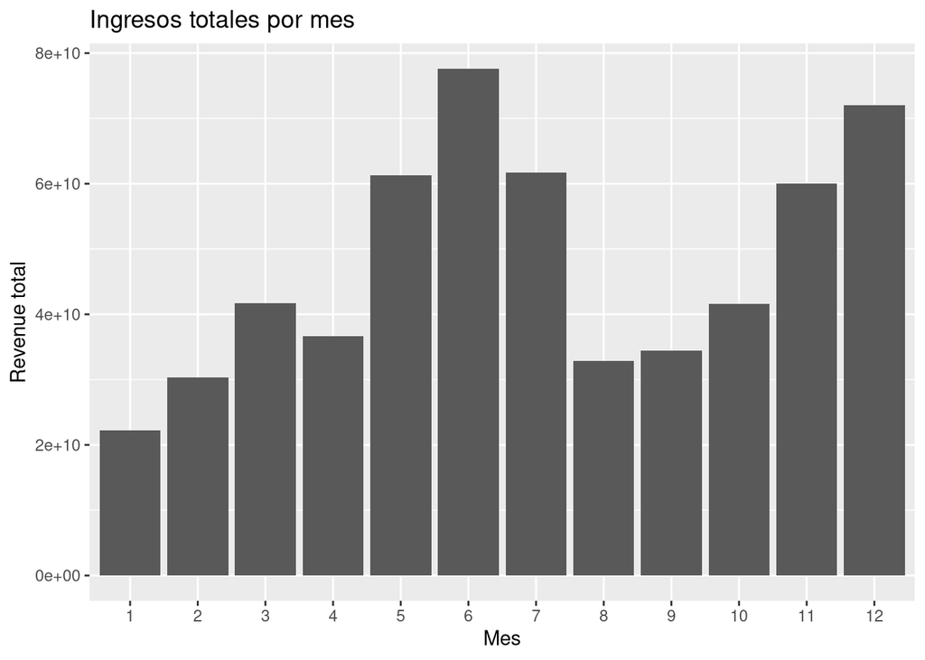

```
## [1] 1656.75
```

## 4.14 ¿Cómo se correlacionan las calificaciones con el éxito comercial?

```
## [1] 0.1063246
```

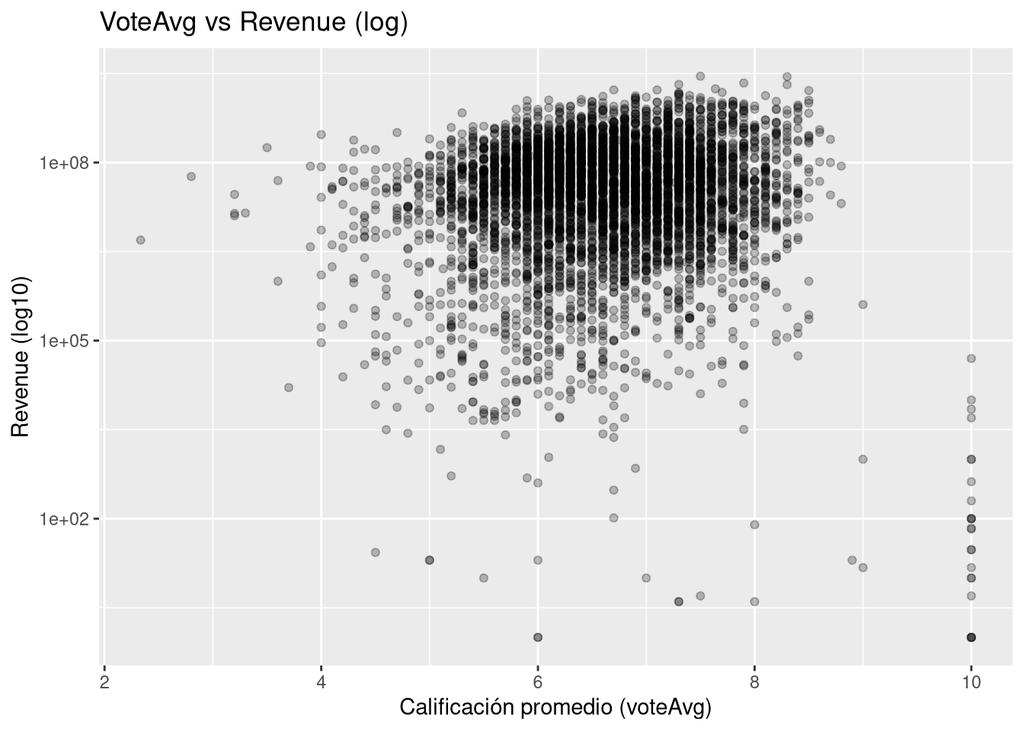

```
## # A tibble: 5 × 3
##   bin    revenue_mediana peliculas
##   <fct>            <dbl>     <int>
## 1 [0,4]         13255913        20
## 2 (4,6]         30068418      1280
## 3 (6,7]         44400000      2335
## 4 (7,8]         45150000      1452
## 5 (8,10]        34934009       209
```

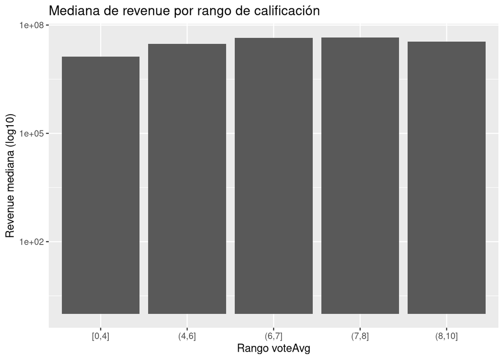

## 4.15 ¿Qué estrategias de marketing, como videos promocionales o páginas oficiales, generan mejores resultados?

```
## # A tibble: 3 × 5
##   has_homepage has_video revenue_prom popularity_prom peliculas
##   <chr>        <chr>            <dbl>           <dbl>     <int>
## 1 Con Web      Sin Video   150830255.           85.2       2537
## 2 Con Web      Con Video     5702633            18.3          3
## 3 Sin Web      Sin Video     3254490.            1.49       129
```

## 4.16 ¿La popularidad del elenco está directamente correlacionada con el éxito de taquilla?

```
## [1] 0.6243066
```

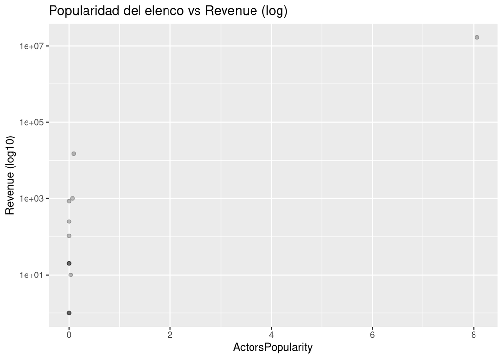

# 5. Preguntas extra (10 puntos)

> Se proponen seis preguntas adicionales (distintas a las anteriores) y se responden con análisis y gráficos.

## Extra 1: ¿Es posible agrupar las películas en categorías financieras basándose en presupuesto e ingresos?

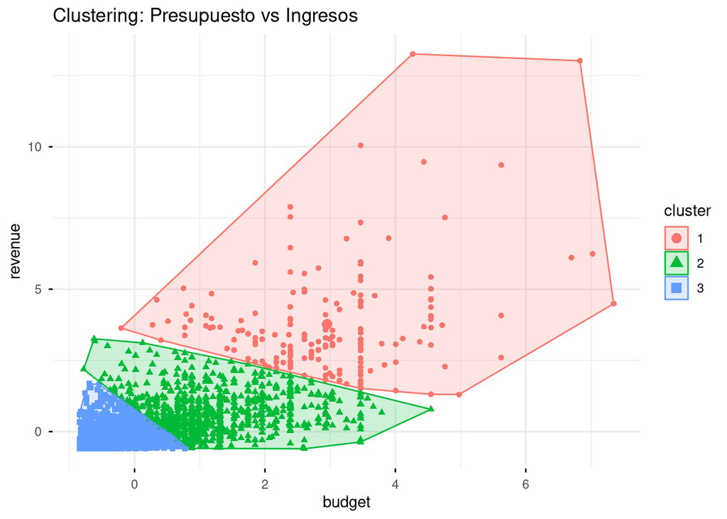

```
##   cluster    budget   revenue
## 1       1 176190145 899005440
## 2       2  94289095 258207095
## 3       3  20084865  55739764
```

## Extra 2: ¿Existen grupos de películas “de culto” (alta calificación, baja popularidad) vs “virales”?

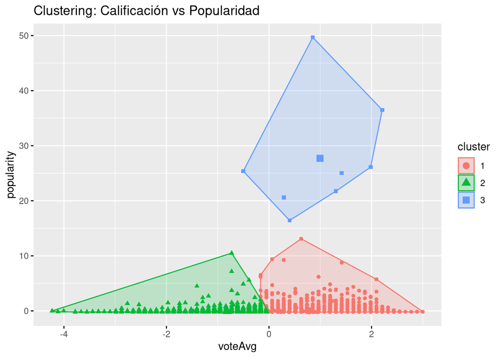

```
##   cluster  voteAvg popularity
## 1       1 7.236344   57.23974
## 2       2 5.819501   36.21563
## 3       3 7.425000 6416.89387
```

## Extra 3: ¿Cuáles son las películas más rentables en términos relativos (ROI)?

```
##                                 title   budget   revenue       ROI
## 12334             Alice in Wonderland  3000000 572000000 189.66667
## 10100 Snow White and the Seven Dwarfs  1488423 184925486 123.24256
## 10305              Gone with the Wind  4000000 402352579  99.58814
## 13592   The Rocky Horror Picture Show  1200000 112892319  93.07693
## 12091                      Cinderella  2900000 263591415  89.89359
## 9992                              Saw  1200000 103911669  85.59306
## 10202      E.T. the Extra-Terrestrial 10500000 792965500  74.52052
## 11178        My Big Fat Greek Wedding  5000000 368744044  72.74881
## 9893                        Star Wars 11000000 775398007  69.49073
## 12019            Saturday Night Fever  3500000 237113184  66.74662
```

## Extra 4: ¿Las coproducciones (varios países) generan más ingresos promedio?

```
##   es_coproduccion   revenue
## 1              No 106977342
## 2              Si 103856831
```

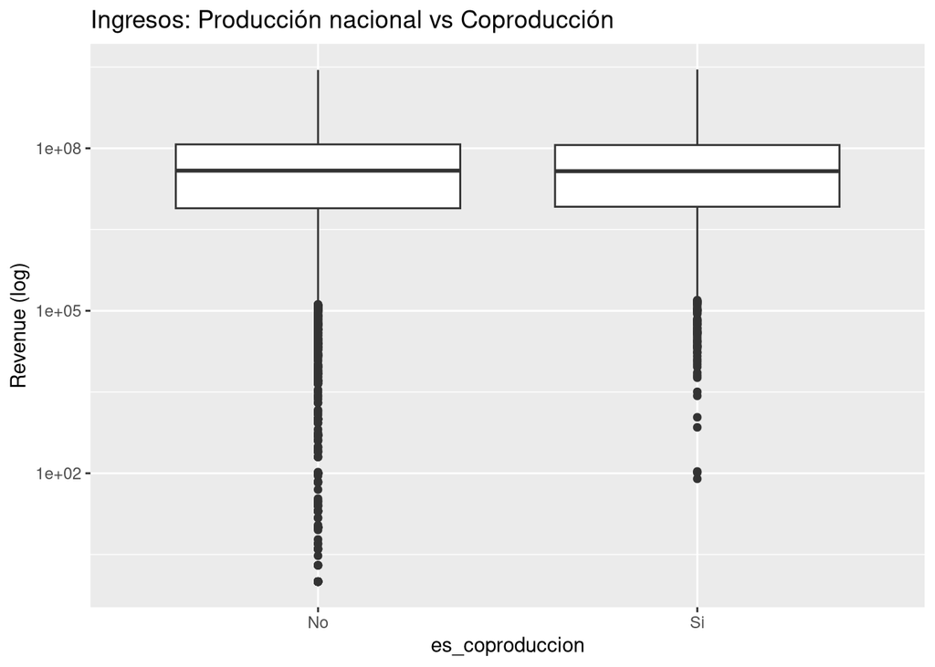

## Extra 5: ¿Existe una duración (runtime) “ideal” que maximice la calificación promedio?

```
##   rango_duracion  voteAvg
## 1        <90 min 2.701265
## 2     90-120 min 5.790743
## 3    120-150 min 6.170026
## 4       >150 min 5.724146
```

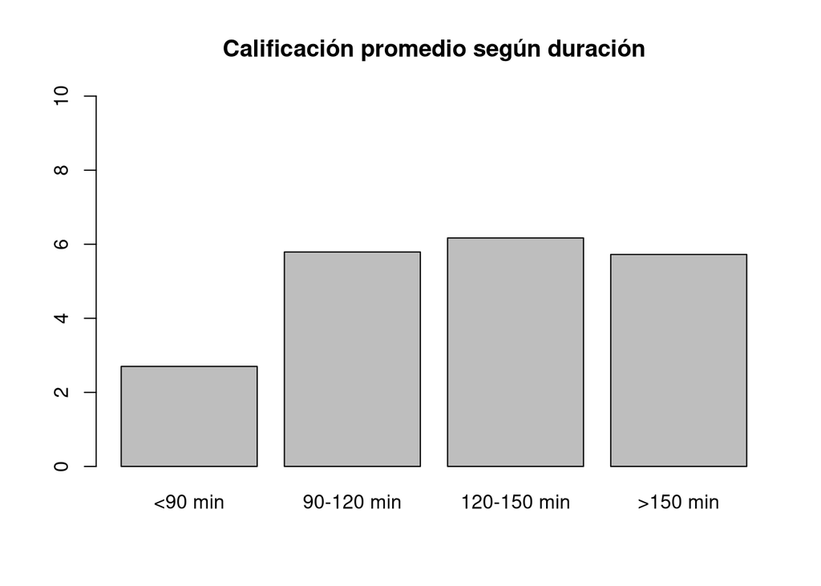

## Extra 6: ¿Se pueden identificar grupos según presupuesto y calificación? (¿El dinero compra buenas críticas?)

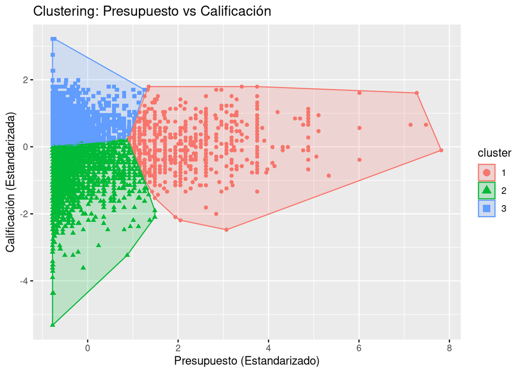

```
##   cluster    budget  voteAvg
## 1       1 136429551 6.705811
## 2       2  25081252 5.873428
## 3       3  16939485 7.510606
```